```python
import pandas as pd
import os
import pandas_profiling
import numpy as np
import matplotlib.pyplot as plt
import seaborn as sns
plt.rcParams['figure.figsize'] = (20, 10)
```

# Desaparecidos en México

**Estadística aplicada 3**

*Pablo Garza Moreno 157869*

*Jerónimo Aranda Barois 150344*

## Introducción

La desaparición forzada en México es un problema muy grave, al día desaparecen personas en este país y de ellos poco se sabe después. Grandes esfuerzos se han hecho por asociaciones civiles para hacer algo al respecto, algunas de ellas han hecho esfuerzos desde el area del análisis de datos. Específicamente queremos agradecer a Data Cívica A.C por recopilar esta valiosísima información y anexamos su propia descripción de su esfuerzo:

> En nuestro país los nombres de las y los desaparecidos no son públicos. Nadie sabe quiénes son, cómo son, cuáles son sus historias. No sabemos nada más que el número de personas que no están.

> Cada tres meses se agregan nuevos al RNPED a la vez que se quitan otros, sin embargo no sabemos quiénes son ni los primeros ni los segundos. Salen del registro sin dejar rastro, sin saber si se quitaron de la base porque fueron encontrados vivos o porque fueron encontrados muertos. Desaparecen dos veces. Este proyecto busca nombrar a las personas desaparecidas y ponerles rostro para que se puedan contar sus historias. Nombrar a las personas desaparecidas en el RNPED significa también la posibilidad de exigir justicia y verdad. Queremos acercarnos a un Registro que realmente sea útil para la búsqueda de personas pero también para la búsqueda de justicia y verdad.

> Un registro que incluye los nombres de quienes han desaparecido permite también darle seguimiento a casos particulares. Si una persona deja de estar en el Registro, debe haber claridad sobre por qué salió del mismo: ¿Encontraron a la persona? ¿La federación atrajo su caso? ¿Existe un acta de defunción? ¿La persona volvió a casa? La forma como está conformado el registro hasta ahora hace imposible responder estas preguntas.

> [Personas desaparecidas.](http://personasdesaparecidas.mx/db/db)

La base de datos completa se puede encontrar en el link anterior, nosotros procederemos a hacer nuestro análisis utilizando una base de datos restringida con el mismo número de registros pero eliminando algunas columnas. Las primeras 2 partes del proyecto serán hechas en Python(profiling y análisis exploratorio) y la última parte en R(Regresión logística).

Aprovechamos para invitarlos la próxima semana a las actividades de **La semana de la desaparición forzada en el ITAM** en la que se presentarán análisis audiovisuales con realidad virtual.

## Profiling

El siguiente código nos permite leer nuestro archivo .csv de datos y convertir los campos cuyo valor original era 'no específicado' en el valor `NaN` que la librería `pandas` reconoce como valor faltante. La última línea permite generar un profiling completo y utiliza la librería `pandas-profiling`, cuya documentación puede ser accedida [aquí](https://github.com/pandas-profiling/pandas-profiling).

```python
missing_values = ['NO ESPECIFICADO','no ESPECIFICADO']
df=pd.read_csv('datos.csv',na_values = missing_values)
df.profile_report(style={'full_width':True})
```

[interactive chart not shown]

El reporte generado anteriormente contiene las siguientes secciones:

- Overview
- Variables
- Correlations
- Missing values
- Sample

### Overview

Esta sección contiene un screening general de lo que es el dataset, es decir, la cantidad de registros, los tipos de variables, la cantidad de valores faltantes entre otras estadísticas importantes.

### Variables

Por cada variable genera un resumen que puede ser visto con mayor detalle haciendo click en **Toggle details**, el resumen incluye la cantidad de valores distintos, los valores más comunes, los valores faltantes y si la variable es númerica genera un histograma e incluye estadísticas interesantes.

### Correlations

Muestra las correlaciones más importantes entre variables en forma de Heatmaps.

### Missing values

Permite rápidamente visualizar la composición del dataset, es decir visualizar los valores faltantes.

### Sample

Permite visualizar una muestra cruda de los datos en tablas, es decir las primeras y últimas ocurrencias del dataset.

## Análisis exploratorio

Veamos el nombre de las variables que tiene nuestro dataset:

```python
df.columns
```

```
Index(['Aparecio', 'Complexion', 'Estado', 'Mes', 'Descripcion', 'Edad',
       'Estatura', 'Sexo'],
      dtype='object')
```

### Variables categóricas

Entre las variables categóricas, la más importante es: `Aparecio` es la que élegimos como la $Y$ de nuestra próxima regresión logística, la respuesta.

**Apareció** es un nombre que elegimos nosotros, pues aunque no significa necesariamente que la persona apareció viva, significa que por alguna razon su nombre fue eliminado de la base de datos con la que datacivica pobla sus tablas.

**Complexion** cada nivel es un tipo de complexión física.

**Estado** alguno de los 32 estados de la república y algunos que no lo especificaron.

**Mes** El mes del año en el que cada registro fue desaparecido.

**Descripcion** Si el reporte de su desaparición contiene alguna referencia textual.

**Edad** La edad a la hora de desaparecer.

**Sexo** que no hace falta describir a profundidad.

#### Aparecio vs. Sexo

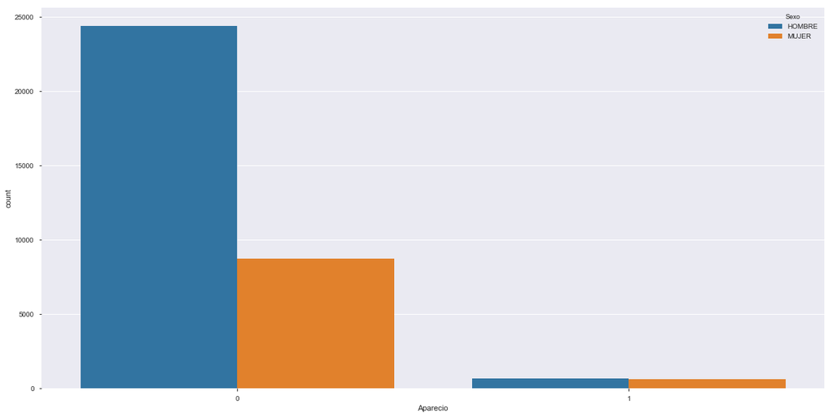

```python
ax = sns.countplot(x="Aparecio", hue="Sexo", data=df)
```

Es evidente que desaparecen más hombres que mujeres, la proporción con la que aparecen más mujeres es muy distinta, recuerden que sin significar que aparecen vivas.

#### Apareció vs. Complexión

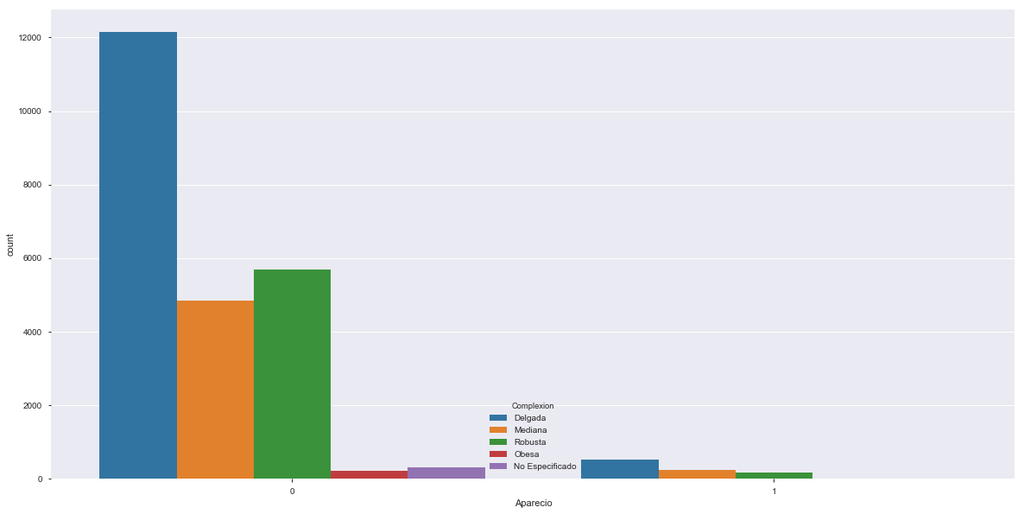

```python
ax = sns.countplot(x="Aparecio", hue="Complexion", data=df)
```

#### Apareció vs. Mes

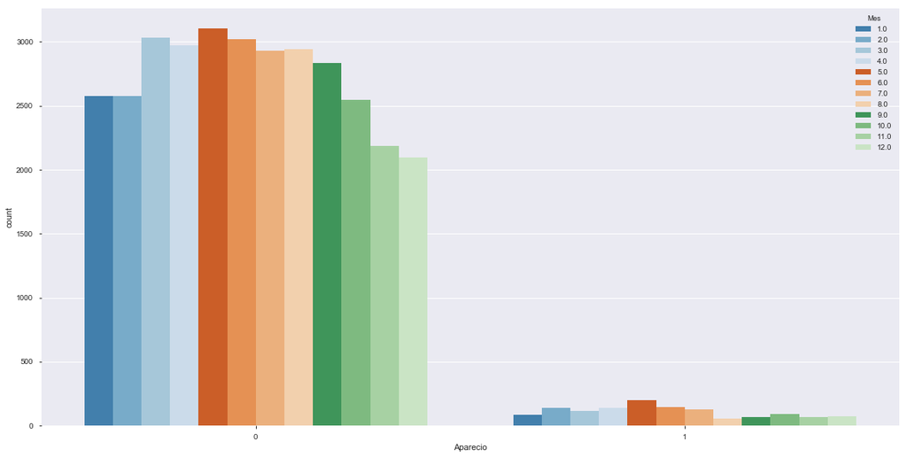

```python
ax = sns.countplot(x="Aparecio", hue="Mes", data=df,palette='tab20c')
```

#### Apareció vs. Estado

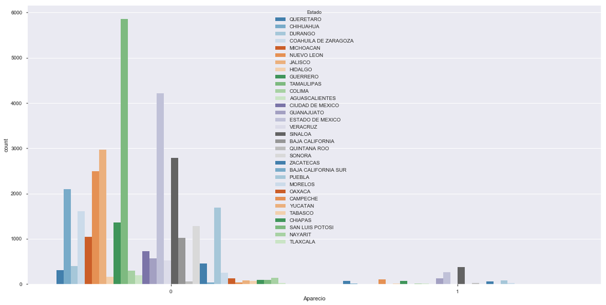

```python
ax = sns.countplot(x="Aparecio", hue="Estado", data=df,palette='tab20c')
```

### Variables numéricas

**Estatura**,**Edad** son las únicas variables numéricas, grafiquémoslas en un scatter plot coloreando cada observación respecto a su aparición.

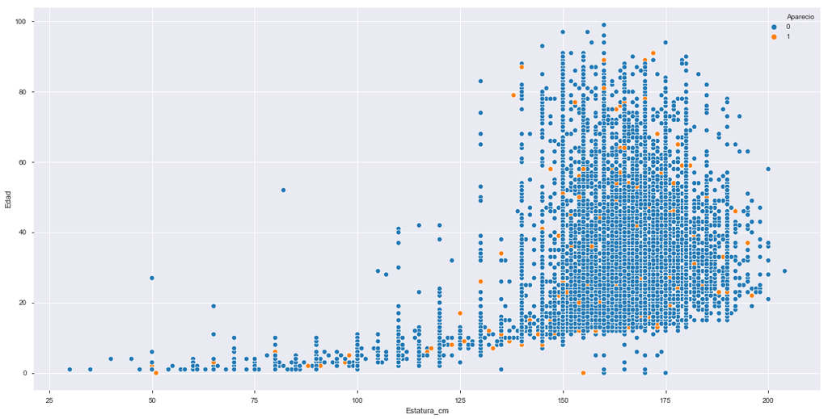

```python
fig, ax = plt.subplots()
df['Estatura_cm']=df.Estatura*100
sns.scatterplot(x='Estatura_cm', y='Edad', hue='Aparecio', data=df,ax=ax)
```

Se puede ver que existe cierta correlación entre las variables, aunque no parecen explicar en gran medida a la **aparición**. Las formas de los clústers podrían tener mucho mayores significados bajo análisis más profundo. Cabe destacar que con una coloración distinta(por **sexo**), se alcanzaba a ver diferencias entre las distribuciones de alturas y edades.

## Regresión logística

```
data <- read.csv("Datos para Regresion.csv")
    data2 <- data %>%
    mutate(Descripcion = ifelse(Descripcion==0,"No", "Si"),
               Descripcion= factor(Descripcion),
               Mes = ifelse(Mes=="NaN", NA, Mes),
               Mes = ifelse(is.na(Mes), round(mean(Mes,na.rm = T)), Mes),
               Edad = ifelse(is.na(Edad), round(mean(Edad,na.rm = T)), Edad),
               Estatura = ifelse(is.na(Estatura), round(mean(Estatura,na.rm = T)), Estatura))

    data2$Complexion <- data2$Complexion %>% fct_collapse('NO ESPECIFICADO'= c("No Especificado", "NO ESPECIFICADO"))

    #sapply(data2, class)
    #summary(data2)
```

```
data <- read.csv("Datos para Regresion.csv")
    data2 <- data %>%
    mutate(Descripcion = ifelse(Descripcion==0,"No", "Si"),
               Descripcion= factor(Descripcion),
               Mes = ifelse(Mes=="NaN", NA, Mes),
               Mes = ifelse(is.na(Mes), round(mean(Mes,na.rm = T)), Mes),
               Edad = ifelse(is.na(Edad), round(mean(Edad,na.rm = T)), Edad),
               Estatura = ifelse(is.na(Estatura), round(mean(Estatura,na.rm = T)), Estatura))

    data2$Complexion <- data2$Complexion %>% fct_collapse('NO ESPECIFICADO'= c("No Especificado", "NO ESPECIFICADO"))

    #sapply(data2, class)
    #summary(data2)
```

```
#Regresion Logistica
n <- nrow(data2)
set.seed(157869)
sampleNum <- sample(seq(1,n),n*.75,replace=F, prob=NULL)

trainData <- data2[sampleNum,]
testData <- data2[-sampleNum,]

logit <- glm(Aparecio~. , family = binomial, data = trainData )

#stargazer(logit, type = "html")
```

|  | *Variable dependiente:* |
| --- | --- |
|  | Aparecio |
| ComplexionMediana | 0.078 |
|  | (0.098) |
| ComplexionNO ESPECIFICADO | -0.596*** |
|  | (0.116) |
| ComplexionObesa | -0.873 |
|  | (0.729) |
| ComplexionRobusta | -0.074 |
|  | (0.115) |
| EstadoBAJA CALIFORNIA | -3.472*** |
|  | (0.776) |
| EstadoBAJA CALIFORNIA SUR | -0.628 |
|  | (1.070) |
| EstadoCAMPECHE | 1.455*** |
|  | (0.548) |
| EstadoCHIAPAS | -1.775* |
|  | (1.060) |
| EstadoCHIHUAHUA | -2.158*** |
|  | (0.450) |
| EstadoCIUDAD DE MEXICO | -15.807 |
|  | (271.612) |
| EstadoCOAHUILA DE ZARAGOZA | -2.583*** |
|  | (0.550) |
| EstadoCOLIMA | -0.458 |
|  | (0.457) |
| EstadoDURANGO | -2.118*** |
|  | (0.779) |
| EstadoESTADO DE MEXICO | -0.387 |
|  | (0.327) |
| EstadoGUANAJUATO | 1.707*** |

[output cut: 59 more lines]

```
#Predicciones

    logProbs <- logit%>% predict(testData, type="response")


    data3 <- testData %>%
      mutate(logitProbs = logProbs,
             predict = ifelse(logitProbs>max(logProbs)/2, 1, 0),
             error = ifelse( Aparecio != predict, 1,0))

    errorRate <- sum(data3$error)/nrow(testData)
    sprintf('La tasa de error de este modelo es %.2f %%' , errorRate*100 )
```

"La tasa de error de este modelo es 4.68%"

```
tabLogit <- table(data3$predict,data3$Aparecio)
kable(tabLogit, caption = "Clasificacion real contra predicción (Columnas es la real)")
```

Clasificacion real contra predicción (Columnas es la real)

|  | 0 | 1 |
| --- | --- | --- |
| 0 | 8160 | 302 |
| 1 | 101 | 48 |

```
kable(round(prop.table(tabLogit, margin=2)*100,2), caption = "Procentajes de Error por clasificacion real")
```

Procentajes de Error por clasificacion real

|  | 0 | 1 |
| --- | --- | --- |
| 0 | 98.78 | 86.29 |
| 1 | 1.22 | 13.71 |

```
#Regresion Logistica sin estados
n <- nrow(data2)
set.seed(157869)
sampleNum2 <- sample(seq(1,n),n*.75,replace=F, prob=NULL)

trainData <- data2[sampleNum,]
testData <- data2[-sampleNum,]

logit2 <- glm(Aparecio ~ Complexion + Mes + Descripcion + Edad + Estatura + Sexo, family = binomial, data = trainData )
#stargazer(logit2, type = "html")
```

|  | *Variable dependiente:* |
| --- | --- |
|  | Aparecio |
| ComplexionMediana | 0.118 |
|  | (0.093) |
| ComplexionNO ESPECIFICADO | -0.181** |
|  | (0.084) |
| ComplexionObesa | -1.126 |
|  | (0.713) |
| ComplexionRobusta | -0.400*** |
|  | (0.110) |
| Mes | -0.046*** |
|  | (0.010) |
| DescripcionSi | -0.309*** |
|  | (0.072) |
| Edad | -0.016*** |
|  | (0.003) |
| Estatura | -0.004** |
|  | (0.002) |
| SexoMUJER | 0.694*** |
|  | (0.071) |
| Constante | -1.820*** |
|  | (0.319) |
| Observaciones | 25,830 |
| Log Likelihood | -4,013.508 |
| Akaike Inf. Crit. | 8,047.016 |
| *Note:* | *p<0.1; **p<0.05; ***p<0.01 |

```
#Predicciones

logProbs2 <- logit2%>% predict(testData, type="response")


data4 <- testData %>%
  mutate(logitProbs = logProbs2,
         predict = ifelse(logitProbs>max(logProbs2)/2, 1, 0),
         error = ifelse( Aparecio != predict, 1,0))

errorRate2 <- sum(data4$error)/nrow(testData)

sprintf('La tasa de error de este modelo es %.2f %%' , errorRate2*100 )
```

"La tasa de error de este modelo es 6.18 %"

```
tabLogit2 <- table(data4$predict,data4$Aparecio)
kable(tabLogit2, caption = "Clasificacion real contra predicción (Columnas es la real) ")
```

Clasificacion real contra predicción (Columnas es la real)

|  | 0 | 1 |
| --- | --- | --- |
| 0 | 8038 | 309 |
| 1 | 223 | 41 |

```
kable(round(prop.table(tabLogit2, margin=2)*100,2), caption = "Procentajes de Error por clasificacion real")
```

Procentajes de Error por clasificacion real

|  | 0 | 1 |
| --- | --- | --- |
| 0 | 97.3 | 88.29 |
| 1 | 2.7 | 11.71 |

## Conclusiones

Primero notemos que en ambos modelos las variables tienen efectos similares. Veamos primero la complexión, la única complexión con efecto positivo es para la complexión mediana, este comportamiento se repite para ambos modelos. Ahora notemos que tanto la edad como la estatura y el mes en el que desaparecen tienen una relación negativa con la posibilidad de que se encuentre al desaparecido. También, es importante notar que la presencia de una descripción al momento del reporte de la persona desapercibida, también tiene un efecto negativo sobre la posibilidad de aparición. Finalmente notemos que hay una relación positiva si el sexo del desaparecido es mujer. Esto, en el contexto del problema nos dice que en general es más dificíl encontrar al desparecido si este es muy alto, de alta edad, hombre y en general de complexión corporal alta y que se haya presentado con una descripción de la víctima. Notemos que para este modelo, casi todos los coeficientes son significativos al nivelo 5%, lo cuál nos habla de una buena presencia de estos modelos cuando no hay ningun otro presente.

Ahora agreguemos la presencia de la entidad federativa, primero notemos que la tasa de error disminuye. También es importante notar que el efecto de la gran mayoría de las idaentidad federativa depende y sigue una tendencia, si muchos desaparenen en estas entidad el efecto será negativo, auqnue no necesariamente el efecto es creciente de acuerdo al porcentaje de desaparecidos por entidad.

La conclusión más importante es la de reconocer a la desaparición como un problema que exige soluciones, otras conclusiones

La calidad de los datos es bastante buena aunque es clara la necesidad de mejores mecanismos de denuncias y mejores prácticas en el manejo de los datos públicos. Maravillas en diseño de políticas públicas se podrían hacer.